# basic concept and syntax

# *basic built-in operations*

## 2. **Very basic syntax**

1. Comments Use `#` to comment.
2. (Especially in R command line,) if want 2 commands in one line, separate with `;`
3. assignment
   1. <CCLD>: when you use, when doing assignment always `<-`, when calling function param, always `=`. But also remember the special case below.
   2. explanation:
      1. similar to assignment of other languages. Can use symbols `=` or `<-`
      2. but R uses = for yet another purpose: associating function arguments with values. E.g., `f(x=3)`.  
         But can also `f(x<-3)`, and in this way after the funciton, `x` is still there since it is global.
      3. Technically, `<-` is a global assignment operator, `=` is a local assignment operator. But the local in the outmost environ is global.
   3. Other notes:
      1. similar to C, the return value of assignment is the value it assigns

         ```
         Fibonacci[1] <- Fibonacci[2] <- 1
         ```

## 3. **math and logic calculation**

1. Operations and precedence

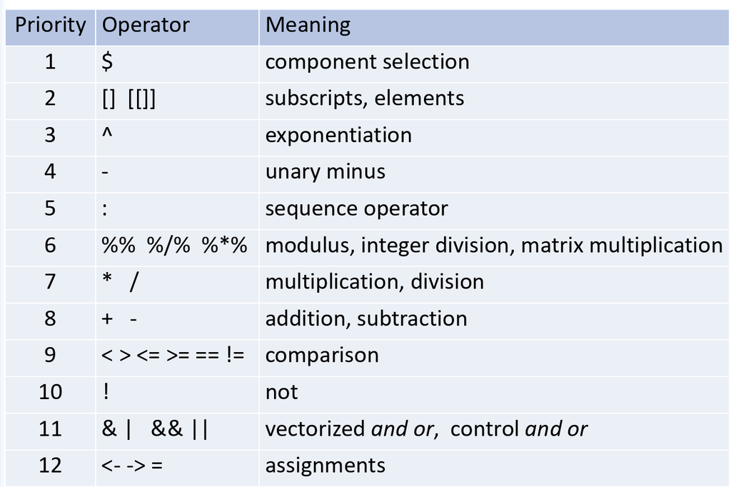

   1. Notes:
      1. Associativity  
         In the same row of the table (which means same priority), use associativity rules.  
         Most operators in R have associativity from left to right.  
         Exponent `^` and leftward assignment (`<-`, `=`) are from right to left.  
         eg.
         1. `5%%3%/%2` means `(5%%3)%/%2` (left to right)
         2. `2^3^2` means `2^(3^2)` (right to left)
      2. Inside `()` rearrange priority
      3. Unary minus means the negative sign (?)
      4. The `&` and `|` operator performs the element-wise comparison and returns a logical vector of the same length as its input.  
         `&&` and `||`: beside is 2 logical expression with value `T` or `F`.
      5. NA involved in any calculation (math / logic) will result in NA
2. Special numbers

   ```
   > 1/0
   [1] Inf

   > 0/0
   [1] NaN
   ```

3. Built-in math functions
   1. sqrt, abs, sin, cos, log, exp
   2. others

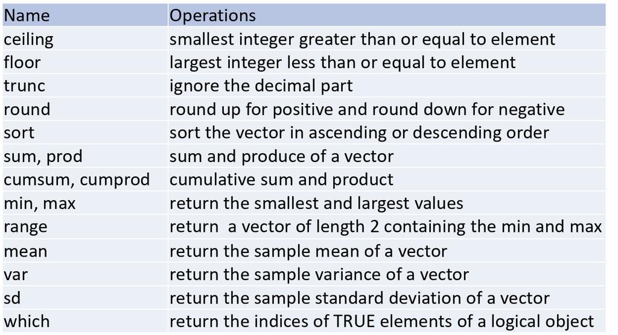

      1. notes / eg use
         1. `ceiling`, `floor`, `trunc`, `round`: note, the return value is still numeric not integer

            ```
            > round(1.5)
            [1] 2
            > class(round(1.5))
            [1] "numeric"
            ```

         2. `round` has a paramm `digit`, indicating the number of decimal places. Default is 0
         3. stats functions like `mean`, `var`, `sd`: if has `NaN` inside, the result is `NaN`

            ```
            mean(c(NaN, 1, 2))
            [1] NaN
            ```

         4. `cumsum`:

            ```
            > cumsum(c(1, 2, 3, 4))
            [1]  1  3  6 10
            ```

   3. other misc
      1. diff(v)  
         return the diff `v[i+1]-v[i]`

         ```
         > diff(c(1, 2, 4))
         [1] 1 2
         ```

4. Built-in logic functions
   1. `all()` and `any()`
      1. functions in R can be used to check if all or any values in a vector evaluate to TRUE for some expression. Return is a single `TRUE` or `FALSE`.
      2. Directly do eg `&&` to multi-ele vector can result in error

## 4. **string operations**

2. `paste`
   1. syntax

      ```
      paste (..., sep = " ", collapse = NULL, recycle0 = FALSE)
      ```

   2. eg

      ```
      > paste("Tree", 1:5)
      [1] "Tree 1" "Tree 2" "Tree 3" "Tree 4" "Tree 5"

      > (nth <- paste0(1:12, c("st", "nd", "rd", rep("th", 9))))
       [1] "1st"  "2nd"  "3rd"  "4th"  "5th"  "6th"  "7th"  "8th"  "9th"  "10th"
      [11] "11th" "12th"
      > month.abb
       [1] "Jan" "Feb" "Mar" "Apr" "May" "Jun" "Jul" "Aug" "Sep" "Oct" "Nov" "Dec"
      > paste(month.abb, "is the", nth, "month of the year.")
       [1] "Jan is the 1st month of the year."  "Feb is the 2nd month of the year."
       [3] "Mar is the 3rd month of the year."  "Apr is the 4th month of the year."
       [5] "May is the 5th month of the year."  "Jun is the 6th month of the year."
       [7] "Jul is the 7th month of the year."  "Aug is the 8th month of the year."
       [9] "Sep is the 9th month of the year."  "Oct is the 10th month of the year."
      [11] "Nov is the 11th month of the year." "Dec is the 12th month of the year."
      ```

## 4. **datatype related opereations**

1. Inspect datatype: see section 1
2. Convert datatype:
   1. Syntax: `as.<type>()`

      ```
      > v = c(1, 2, 3, 'a', 'b', 4)
      > as.numeric(v)
      [1]  1  2  3 NA NA  4
      > as.logical(v)
      [1] NA NA NA NA NA NA
      > as.character(v)   # actually originally v is of mode character
      [1] "1" "2" "3" "a" "b" "4"
      ```

   2. Note: can cause `NA` if not able to convert
   3. Note: can also have `as.interger()`

      But note:

      ```
      > as.integer(1.5)
      [1] 1
      ```

      So the way to check for integer:

      ```
      (input-floor(input)>0)
      ```

# *tricky*

1. `y<-x<2` is actually: `y = (x<2)`